# Lab 2, CP 4: AnÃ¡lise completa

# Pergunta 1

### What is our daily overall clickthrough rate? How does it vary between the groups?

Para respondermos essa pergunta, utilizaremos duas variaveis do nosso conjunto de dados, são elas: group e session_start_date. Para observamos os dados utilizaremos dois gráficos de linha que representam a quantidade de sessões no total e por grupos:

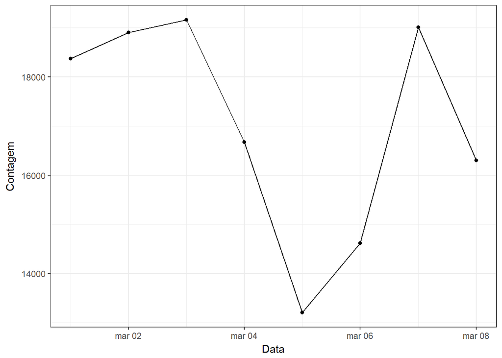

```r
buscas %>%
    mutate(date = floor_date(session_start_date, unit = "day")) %>%
    count(date) %>%
    ggplot(aes(x = date, y = n)) +
    xlab("Data") +
    ylab("Contagem") +
    geom_line()+
    geom_point()
```

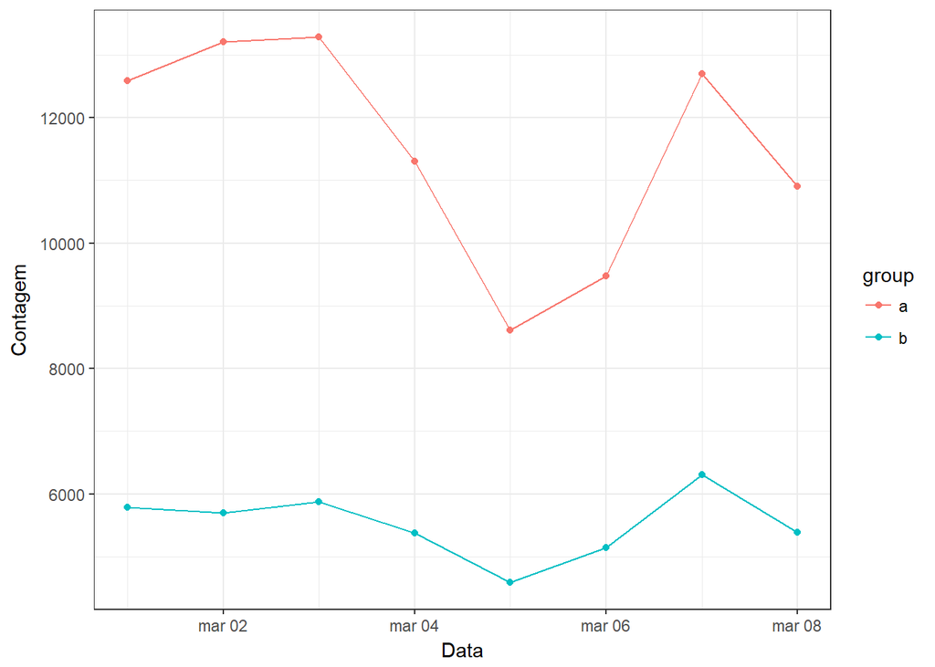

```r
buscas %>%
    mutate(date = floor_date(session_start_date, unit = "day")) %>%
    count(date, group) %>%
    ggplot(aes(x = date, y = n, fill = group, color = group)) +
    xlab("Data") +
    ylab("Contagem") +
    geom_line()+
    geom_point()
```

```r
min(buscas$session_start_date)
```

```
## [1] "2016-03-01 00:00:02 UTC"
```

```r
max(buscas$session_start_date)
```

```
## [1] "2016-03-08 20:24:32 UTC"
```

Além disso, podemos perceber através do gráfico de dispersão abaixo uma grande presença de sessões com 0 ou 1 cliques, concentrando grande parte dos pontos na parte inferior do gráfico.

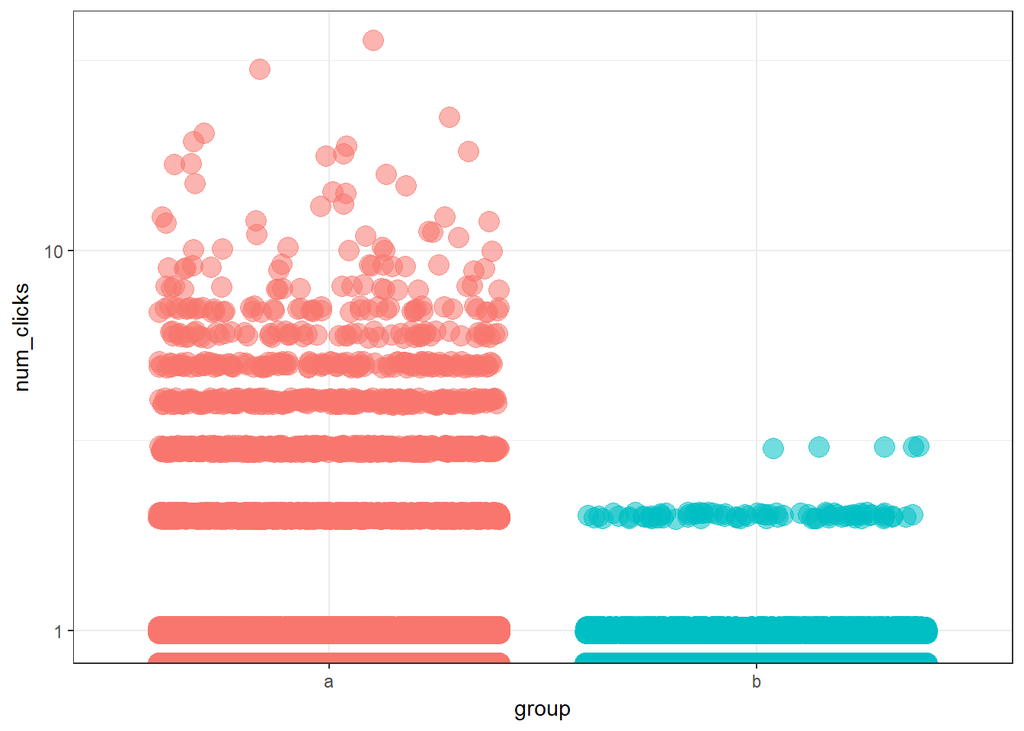

```r
buscas %>%
    ggplot(aes(x = group, y = num_clicks)) +
    geom_jitter(aes(alpha = .4, width = .2, size = .8, color = group)) +
    scale_y_log10() +
  theme(plot.title = element_text(hjust = 0.5), legend.position="none")
```

# Pergunta 2

### Which results do people tend to try first?

Para responder essa pergunta utilizaremos a variavel click_position, onde podemos observar que tanto para a moda como para a mediana os valores se concentram em 1.

```r
summary(buscas$click_position)
```

```
##    Min. 1st Qu.  Median    Mean 3rd Qu.    Max.    NA's
##    1.00    1.00    1.00    3.93    2.00 4103.00  102899
```

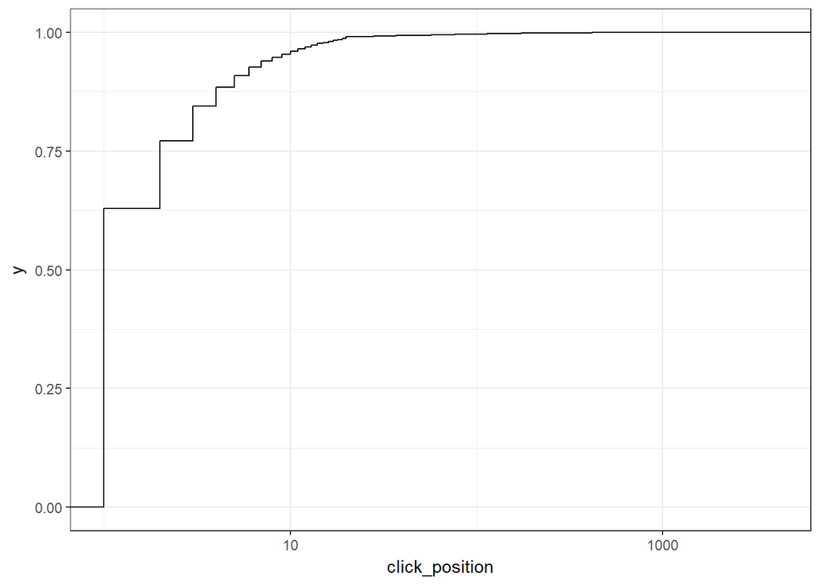

```r
buscas %>%
    ggplot(aes(x = click_position)) +
    scale_x_log10() +
    stat_ecdf()
```

```r
statmod <- function(x) {
z <- table(as.vector(x))
names(z)[z == max(z)]
}

statmod(buscas$click_position)
```

```
## [1] "1"
```

### How does it change day-to-day?

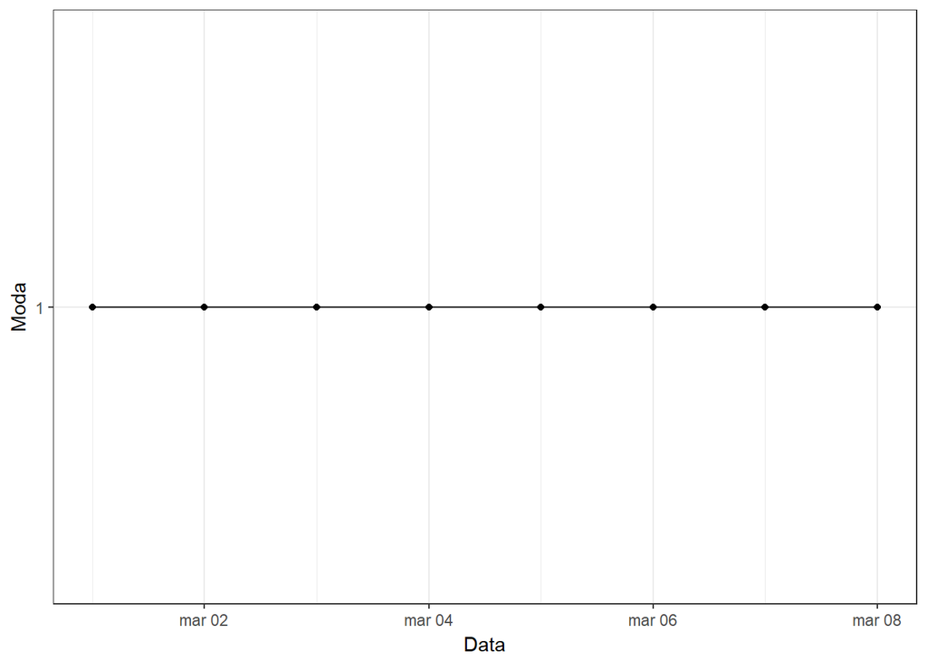

```r
buscas %>%
    mutate(date = floor_date(session_start_date, unit = "day")) %>%
    mutate(moda = statmod(click_position)) %>%
    count(date, moda) %>%
    ggplot(aes(x = date, y = moda)) +
    xlab("Data") +
    ylab("Moda") +
    geom_line() +
    geom_point()
```

# Pergunta 3

### What is our daily overall zero results rate? How does it vary between the groups?

Em relação a taxa de resultados zero podemos observar uma presença significativa nos dados, conforme o gráfico que compara a porcentagem de sessões por dia que retornaram 0 resultados entre todos os dados.

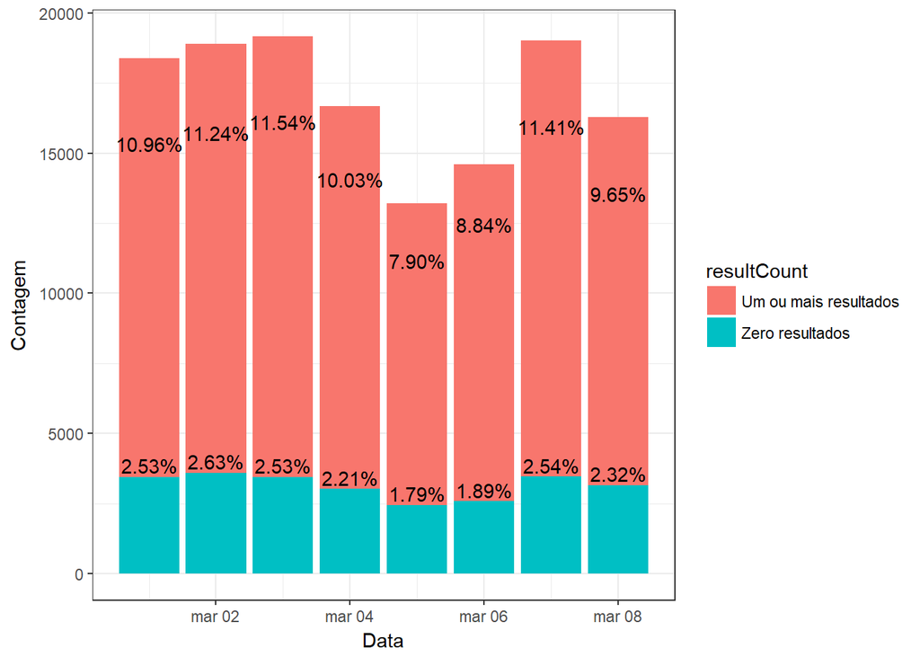

```r
buscas %>%
    mutate(date = floor_date(session_start_date, unit = "day")) %>%
    mutate(resultCount = ifelse(buscas$results > 0, "Um ou mais resultados", "Zero resultados")) %>%
    count(date, resultCount) %>%
    ggplot(aes(x = date, y = n, fill = resultCount)) +
    xlab("Data") +
    ylab("Contagem") +
    geom_col() +
    geom_text(aes(label=sprintf("%0.2f%%",(n/nrow(buscas)) * 100)), position=position_dodge(width=0.5), vjust=-0.25)
```

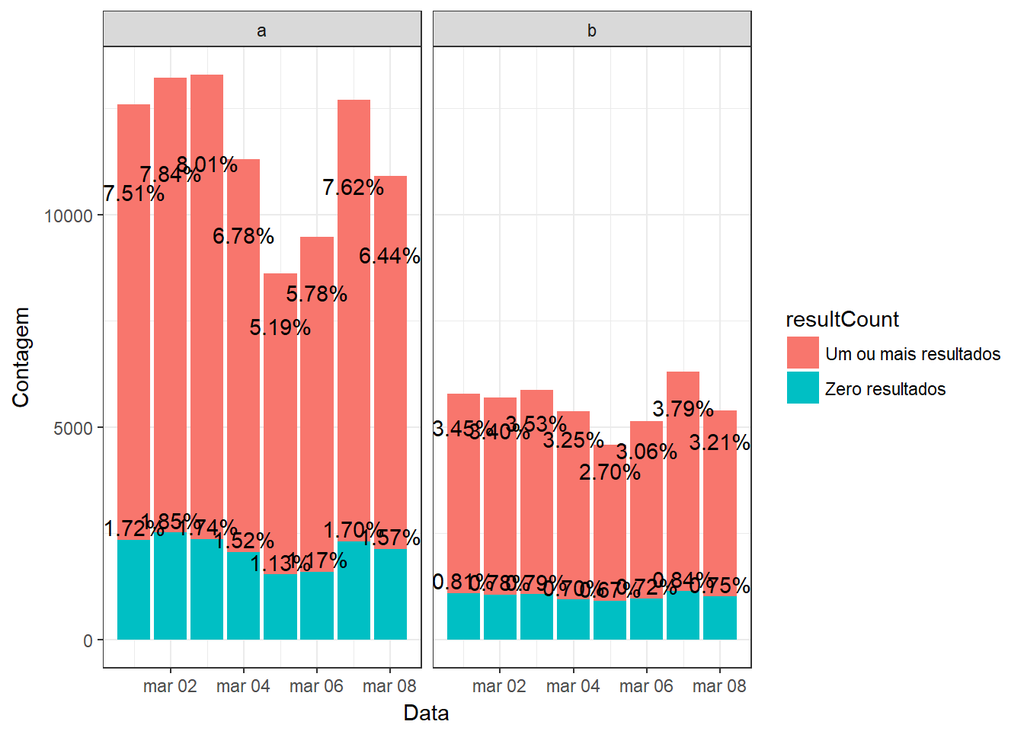

```r
buscas %>%
    mutate(date = floor_date(session_start_date, unit = "day")) %>%
    mutate(resultCount = ifelse(buscas$results > 0, "Um ou mais resultados", "Zero resultados")) %>%
    count(date, resultCount, group) %>%
    ggplot(aes(x = date, y = n, fill = resultCount)) +
    xlab("Data") +
    facet_grid(~group) +
    ylab("Contagem") +
    geom_col()+
    geom_text(aes(label=sprintf("%0.2f%%",(n/nrow(buscas)) * 100)), position=position_dodge(width=0.2), vjust=-0.25)
```

# Pergunta 4

### Let session length be approximately the time between the first event and the last event in a session. Choose a variable from the dataset and describe its relationship to session length. Visualize the relationship.

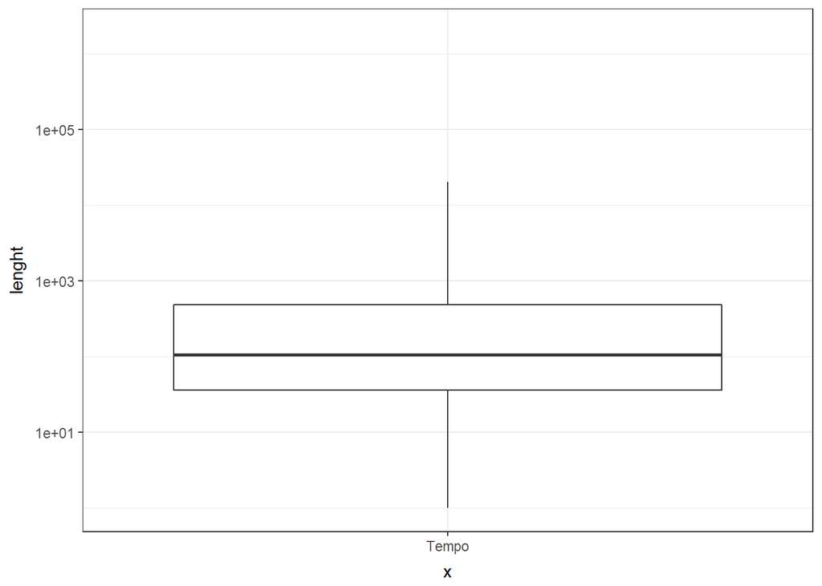

```r
buscas %>%
    mutate(lenght = buscas$session_finish_timestamp - buscas$session_start_timestamp) %>%
    ggplot(aes(x = "Tempo", y = lenght)) +
    geom_boxplot(outlier.shape=NA) +
    scale_y_log10()
```

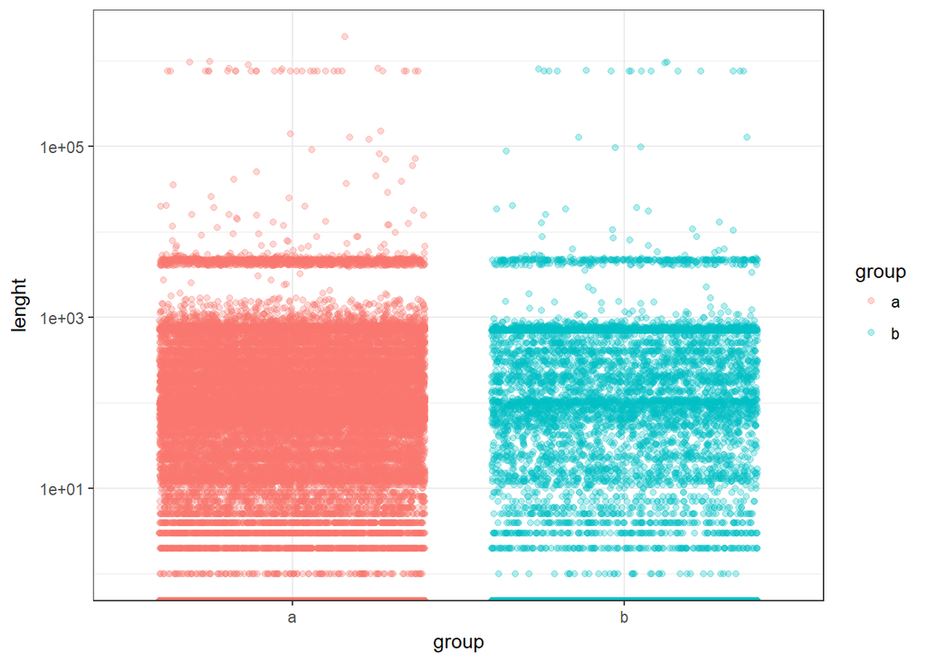

```r
buscas %>%
    mutate(lenght = buscas$session_finish_timestamp - buscas$session_start_timestamp) %>%
    ggplot(aes(x = group, y = lenght, color = group)) +
    scale_y_log10() +
    geom_jitter(alpha = .3)
```

```r
summary(filter(mutate(buscas,lenght = buscas$session_finish_timestamp - buscas$session_start_timestamp), group== "a")$lenght)
```

```
##      Min.   1st Qu.    Median      Mean   3rd Qu.      Max.
##       0.0       0.0       0.0     443.7      13.0 1916457.0
```

```r
summary(filter(mutate(buscas,lenght = buscas$session_finish_timestamp - buscas$session_start_timestamp), group== "b")$lenght)
```

```
##     Min.  1st Qu.   Median     Mean  3rd Qu.     Max.
##      0.0      0.0      0.0    394.1      0.0 958199.0
```